# model-performance-tree

Laura Winger

4/24/2018

### Load the basic decision tree model analysis

Load the analysis in the source files of this project which fits all of the basic linear models (regression and classification).

```
##
## Regression tree:
## rpart(formula = rul ~ sensor_measurement_2 + sensor_measurement_3 +
##     sensor_measurement_4 + sensor_measurement_6 + sensor_measurement_7 +
##     sensor_measurement_8 + sensor_measurement_9 + sensor_measurement_11 +
##     sensor_measurement_12 + sensor_measurement_13 + sensor_measurement_14 +
##     sensor_measurement_15 + sensor_measurement_17 + sensor_measurement_20 +
##     sensor_measurement_21, data = train.FD001, method = "anova")
##
## Variables actually used in tree construction:
## [1] sensor_measurement_11 sensor_measurement_4  sensor_measurement_9
##
## Root node error: 97880908/20631 = 4744.4
##
## n= 20631
##
##         CP nsplit rel error  xerror      xstd
## 1 0.363710      0   1.00000 1.00011 0.0092929
## 2 0.064595      1   0.63629 0.63639 0.0074428
## 3 0.045557      2   0.57170 0.57311 0.0070566
## 4 0.037306      3   0.52614 0.52890 0.0066716
## 5 0.012612      4   0.48883 0.49220 0.0062264
## 6 0.010000      5   0.47622 0.47994 0.0060421
## Call:
## rpart(formula = rul ~ sensor_measurement_2 + sensor_measurement_3 +
##     sensor_measurement_4 + sensor_measurement_6 + sensor_measurement_7 +
##     sensor_measurement_8 + sensor_measurement_9 + sensor_measurement_11 +
##     sensor_measurement_12 + sensor_measurement_13 + sensor_measurement_14 +
##     sensor_measurement_15 + sensor_measurement_17 + sensor_measurement_20 +
##     sensor_measurement_21, data = train.FD001, method = "anova")
##   n= 20631
##
##           CP nsplit rel error    xerror        xstd
## 1 0.36370964      0 1.0000000 1.0001083 0.009292892
## 2 0.06459471      1 0.6362904 0.6363855 0.007442813
## 3 0.04555683      2 0.5716956 0.5731093 0.007056552
## 4 0.03730552      3 0.5261388 0.5289029 0.006671640
## 5 0.01261162      4 0.4888333 0.4922006 0.006226425
## 6 0.01000000      5 0.4762217 0.4799441 0.006042129
##
```

[output cut: 92 more lines]

```
##   Surrogate splits:
##       sensor_measurement_12 < 521.125  to the left,  agree=0.697, adj=0.111, (0 split)
##       sensor_measurement_7  < 552.985  to the left,  agree=0.686, adj=0.080, (0 split)
##       sensor_measurement_8  < 2388.145 to the right, agree=0.684, adj=0.074, (0 split)
##       sensor_measurement_13 < 2388.145 to the right, agree=0.683, adj=0.070, (0 split)
##       sensor_measurement_20 < 38.725   to the left,  agree=0.681, adj=0.064, (0 split)
##
## Node number 15: 5937 observations
##   mean=162.0187, MSE=2993.365
##
## Node number 28: 2439 observations
##   mean=106.681, MSE=2324.964
##
## Node number 29: 4713 observations
##   mean=134.3947, MSE=3004.061
```

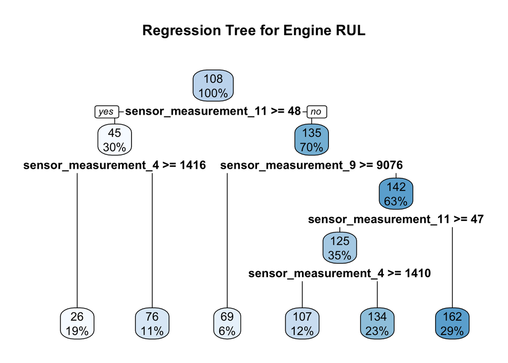

```
##
## Classification tree:
## rpart(formula = factor(class_label) ~ sensor_measurement_2 +
##     sensor_measurement_3 + sensor_measurement_4 + sensor_measurement_6 +
##     sensor_measurement_7 + sensor_measurement_8 + sensor_measurement_9 +
##     sensor_measurement_11 + sensor_measurement_12 + sensor_measurement_13 +
##     sensor_measurement_14 + sensor_measurement_15 + sensor_measurement_17 +
##     sensor_measurement_20 + sensor_measurement_21, data = train.FD001,
##     method = "class")
##
## Variables actually used in tree construction:
## [1] sensor_measurement_11 sensor_measurement_15 sensor_measurement_4
## [4] sensor_measurement_7  sensor_measurement_9
##
## Root node error: 3100/20631 = 0.15026
##
## n= 20631
##
##         CP nsplit rel error  xerror     xstd
## 1 0.546452      0   1.00000 1.00000 0.016556
## 2 0.040968      1   0.45355 0.45355 0.011676
## 3 0.040323      2   0.41258 0.43323 0.011430
## 4 0.035806      3   0.37226 0.38387 0.010802
## 5 0.013065      4   0.33645 0.34323 0.010247
## 6 0.012258      6   0.31032 0.33968 0.010197
## 7 0.010000      7   0.29806 0.32806 0.010030
## Call:
## rpart(formula = factor(class_label) ~ sensor_measurement_2 +
##     sensor_measurement_3 + sensor_measurement_4 + sensor_measurement_6 +
##     sensor_measurement_7 + sensor_measurement_8 + sensor_measurement_9 +
##     sensor_measurement_11 + sensor_measurement_12 + sensor_measurement_13 +
##     sensor_measurement_14 + sensor_measurement_15 + sensor_measurement_17 +
##     sensor_measurement_20 + sensor_measurement_21, data = train.FD001,
##     method = "class")
##   n= 20631
##
##           CP nsplit rel error    xerror       xstd
## 1 0.54645161      0 1.0000000 1.0000000 0.01655626
## 2 0.04096774      1 0.4535484 0.4535484 0.01167627
## 3 0.04032258      2 0.4125806 0.4332258 0.01143036
```

[output cut: 163 more lines]

```
##       sensor_measurement_12 < 520.325  to the right, agree=0.653, adj=0.307, (0 split)
##       sensor_measurement_20 < 38.665   to the right, agree=0.622, adj=0.243, (0 split)
##       sensor_measurement_13 < 2388.185 to the left,  agree=0.619, adj=0.238, (0 split)
##       sensor_measurement_3  < 1596.855 to the left,  agree=0.608, adj=0.217, (0 split)
##       sensor_measurement_11 < 47.915   to the left,  agree=0.606, adj=0.212, (0 split)
##
## Node number 50: 189 observations
##   predicted class=0  expected loss=0.3809524  P(node) =0.009160971
##     class counts:   117    72
##    probabilities: 0.619 0.381
##
## Node number 51: 189 observations
##   predicted class=1  expected loss=0.2857143  P(node) =0.009160971
##     class counts:    54   135
##    probabilities: 0.286 0.714
```

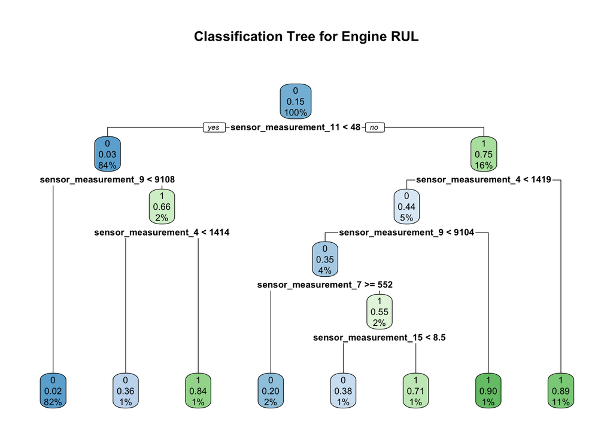

### Examine the regression decision tree model performance for predicting Remaining Useful Life (RUL)

This model is seeking to answer the question: **How many cycles are there (starting now) before the engine will fail?**

The root mean square error of the basic model is 36.2169189 days. However, there were 35 predictions (out of 100) for the end of life that were more than 30 cycles after the actual engine failure. This means that the model FPS success is FALSE.

### Examine the classification decision tree model performance for classifying whether or not the engine will fail in the next 30 days

This model is seeking to answer the question: **Will this engine fail in the next 30 cycles?**

```
## Confusion Matrix and Statistics
##
##           Reference
## Prediction  0  1
##          0 74  7
##          1  1 18
##
##                Accuracy : 0.92
##                  95% CI : (0.8484, 0.9648)
##     No Information Rate : 0.75
##     P-Value [Acc > NIR] : 1.209e-05
##
##                   Kappa : 0.7681
##  Mcnemar's Test P-Value : 0.0771
##
##             Sensitivity : 0.7200
##             Specificity : 0.9867
##          Pos Pred Value : 0.9474
##          Neg Pred Value : 0.9136
##              Prevalence : 0.2500
##          Detection Rate : 0.1800
##    Detection Prevalence : 0.1900
##       Balanced Accuracy : 0.8533
##
##        'Positive' Class : 1
##
```

The confusion matrix for this model with an optimal threshold of 0.1999358 is shown. The sensitivity / true positive rate of this model is 0.72. This means that the model FPS success is FALSE because no engine failure can be misclassified (missed).